# Sequence abundances in community

Chang-Yu Chang

2021-01-28

# Read community sequences

There are two OTU tables and I named them arbitrarily:

1. `communities_abundance`: raw data from Nanxi
2. `communities_abundance_syl`: curated community ESV table from Sylvie

I formated the data.frame so that both of them have the following variables:

In `communities_abundance_syl`, there are other parameters

- `CarbonSource`: the carbon source used for assembly
- `Order`, `Family`, and `Genus`: SILVA assigned taxonomy

| SampleID | Community | Transfer | Abundance | RelativeAbundance | CommunityESVID | ESV |
| --- | --- | --- | --- | --- | --- | --- |
| Original-T0-X1 | C1Rpool | 0 | 26493 | 0.2859 | 1 | GCAAGCGTTAATCGGAATTACTGGGCGTAAAGCGCACGCAGGCGGTCTGTTAAGTCAGAT…… |
| Original-T0-X1 | C1Rpool | 0 | 26471 | 0.2857 | 2 | GCAAGCGTTAATCGGAATTACTGGGCGTAAAGCGCACGCAGGCGGTTTGTTAAGTCAGAT…… |
| Original-T0-X1 | C1Rpool | 0 | 5894 | 0.0636 | 3 | GCAAGCGTTAATCGGAATTACTGGGCGTAAAGCGCACGCAGGCGGTCTGTCAAGTCGGAT…… |
| Original-T0-X1 | C1Rpool | 0 | 4834 | 0.0522 | 4 | GCAAGCGTTAATCGGAATTACTGGGCGTAAAGCGCACGCAGGCGGTCTGTCAAGTCGGAT…… |
| Original-T0-X1 | C1Rpool | 0 | 3907 | 0.0422 | 5 | GCAAGCGTTAATCGGAATTACTGGGCGTAAAGCGCGCGTAGGTGGTTTGTTAAGTTGGAT…… |
| Original-T0-X1 | C1Rpool | 0 | 3084 | 0.0333 | 6 | GCAAGCGTTAATCGGAATTACTGGGCGTAAAGCGCGCGTAGGTGGTTTGTTAAGTTGAAT…… |
| Original-T0-X1 | C1Rpool | 0 | 2735 | 0.0295 | 7 | GCAAGCGTTAATCGGAATTACTGGGCGTAAAGCGCGCGTAGGTGGTTTGTTAAGTTGGAT…… |
| Original-T0-X1 | C1Rpool | 0 | 1874 | 0.0202 | 8 | GCAAGCGTTAATCGGAATTACTGGGCGTAAAGCGCACGCAGGCGGTCTGTCAAGTCGGAT…… |
| Original-T0-X1 | C1Rpool | 0 | 1819 | 0.0196 | 9 | GCAAGCGTTAATCGGAATTACTGGGCGTAAAGCGCACGCAGGCGGTCTGTCAAGTCAGAT…… |
| Original-T0-X1 | C1Rpool | 0 | 1467 | 0.0158 | 10 | GCAAGCGTTAATCGGAATTACTGGGCGTAAAGCGCACGCAGGCGGTCTGTTAAGTCAGAT…… |

[output cut: 990 more lines]

| SampleID | CarbonSource | Community | Transfer | RelativeAbundance | CommunityESVID | ESV | Order | Family | Genus |
| --- | --- | --- | --- | --- | --- | --- | --- | --- | --- |
| Citrate.0.0.12 | Citrate | C1R1 | 12 | 0.6110984762 | Pseudomonas.2 | GCAAGCGTTAATCGGAATTACTGGGCGTAAAGCGCGCGTAGGTGGTTCGTTAAGTTGGAT…… | Pseudomonadales | Pseudomonadaceae | Pseudomonas |
| Citrate.0.0.12 | Citrate | C1R1 | 12 | 0.3593359108 | Enterobacteriaceae | GCAAGCGTTAATCGGAATTACTGGGCGTAAAGCGCACGCAGGCGGTCTGTCAAGTCGGAT…… | Enterobacteriales | Enterobacteriaceae | Enterobacteriaceae |
| Citrate.0.0.12 | Citrate | C1R1 | 12 | 0.0266090516 | Stenotrophomonas.1 | GCAAGCGTTACTCGGAATTACTGGGCGTAAAGCGTGCGTAGGTGGTCGTTTAAGTCTGTT…… | Xanthomonadales | Xanthomonadaceae | Stenotrophomonas |
| Citrate.0.0.12 | Citrate | C1R1 | 12 | 0.0013645668 | Pseudomonas | GCAAGCGTTAATCGGAATTACTGGGCGTAAAGCGCGCGTAGGTGGTTTGTTAAGTTGGAT…… | Pseudomonadales | Pseudomonadaceae | Pseudomonas |
| Citrate.0.0.12 | Citrate | C1R1 | 12 | 0.0009097112 | Pseudomonas.4 | GCAAGCGTTAATCGGAATTACTGGGCGTAAAGCGCGCGTAGGTGGTTCGTTAAGTTGAAT…… | Pseudomonadales | Pseudomonadaceae | Pseudomonas |
| Citrate.0.0.12 | Citrate | C1R1 | 12 | 0.0004548556 | Chryseobacterium.2 | GCAAGCGTTATCCGGATTTATTGGGTTTAAAGGGTCCGTAGGCGGGCCTGTAAGTCAGTG…… | Flavobacteriales | Flavobacteriaceae | Chryseobacterium |
| Citrate.0.0.12 | Citrate | C1R1 | 12 | 0.0002274278 | Pseudomonas.1 | GCAAGCGTTAATCGGAATTACTGGGCGTAAAGCGCGCGTAGGTGGTTCGTTAAGTTGGAT…… | Pseudomonadales | Pseudomonadaceae | Pseudomonas |
| Glucose.0.0.12 | Glucose | C1R1 | 12 | 0.4316579486 | Pseudomonas.2 | GCAAGCGTTAATCGGAATTACTGGGCGTAAAGCGCGCGTAGGTGGTTCGTTAAGTTGGAT…… | Pseudomonadales | Pseudomonadaceae | Pseudomonas |
| Glucose.0.0.12 | Glucose | C1R1 | 12 | 0.3220377530 | Enterobacteriaceae | GCAAGCGTTAATCGGAATTACTGGGCGTAAAGCGCACGCAGGCGGTCTGTCAAGTCGGAT…… | Enterobacteriales | Enterobacteriaceae | Enterobacteriaceae |
| Glucose.0.0.12 | Glucose | C1R1 | 12 | 0.1974073232 | Citrobacter | GCAAGCGTTAATCGGAATTACTGGGCGTAAAGCGCACGCAGGCGGTCTGTCAAGTCGGAT…… | Enterobacteriales | Enterobacteriaceae | Citrobacter |

[output cut: 990 more lines]

Community richness along transfers based on `communities_abundance`

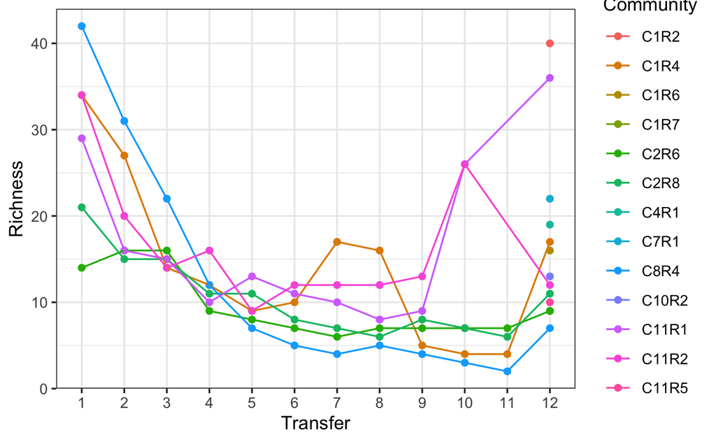

# Match community ESVs and isolate Sanger sequences

IUPAC notation for DNA base pairs

W, S, M, K, R, Y represent two possiblities for one base pair B, D, H, V represent three possiblitieis N means any nucleotide (but not a gap)

I tested five alignment methods in `Biostrings::pairwiseAlignment()`

| SampleID | Community | Family | RelativeAbundance | CommunityESVID | ESV | ExpID | IsolateID | IsolateGenus | IsolateSangerSequence | AlignmentType | ConsensusLength | BasePairGap | BasePairMismatch | AlignmentScore |
| --- | --- | --- | --- | --- | --- | --- | --- | --- | --- | --- | --- | --- | --- | --- |
| Glucose.0.1.12 | C1R2 | Pseudomonadaceae | 0.4564475779 | Pseudomonas.2 | GCAAGCGTTAATCGGAATTACTGGGCGTAAAGCGCGCGTAGGTGGTTCGTTAAGTTGGAT…… | 1.2.A.1 | 259 | Citrobacter | TACGGGAGGCAGCAGTGGGGAATATTGCACAATGGGCGCAAGCCTGATGCAGCCATGCCG…… | global | 233 | 0 | 31 | -1498.56445 |
| Glucose.0.1.12 | C1R2 | Pseudomonadaceae | 0.4564475779 | Pseudomonas.2 | GCAAGCGTTAATCGGAATTACTGGGCGTAAAGCGCGCGTAGGTGGTTCGTTAAGTTGGAT…… | 1.2.A.3 | 428 | Pseudomonas | TCGGATTAGCTAGTTGGTGAGGTAATGGCTCACCAAGGCGACGATCCGTAACTGGTCTGA…… | global | 233 | 0 | 0 | -2662.23779 |
| Glucose.0.1.12 | C1R2 | Pseudomonadaceae | 0.4564475779 | Pseudomonas.2 | GCAAGCGTTAATCGGAATTACTGGGCGTAAAGCGCGCGTAGGTGGTTCGTTAAGTTGGAT…… | 1.2.A.5 | 364 | Serratia | TAGGCGACGATCCCTAGCTGGTCTGAGAGGATGACCAGCCACACTGGAACTGAGACACGG…… | global | 233 | 0 | 37 | -2800.81104 |
| Glucose.0.1.12 | C1R2 | Pseudomonadaceae | 0.4564475779 | Pseudomonas.2 | GCAAGCGTTAATCGGAATTACTGGGCGTAAAGCGCGCGTAGGTGGTTCGTTAAGTTGGAT…… | 1.2.B.6 | 432 | Pseudomonas | TAGGCGACGATCCGTAACTGGTCTGAGAGGATGATCAGTCACACTGGAACTGAGACACGG…… | global | 233 | 0 | 3 | -2196.12256 |
| Glucose.0.1.12 | C1R2 | Enterobacteriaceae | 0.4043666136 | Citrobacter | GCAAGCGTTAATCGGAATTACTGGGCGTAAAGCGCACGCAGGCGGTCTGTCAAGTCGGAT…… | 1.2.A.1 | 259 | Citrobacter | TACGGGAGGCAGCAGTGGGGAATATTGCACAATGGGCGCAAGCCTGATGCAGCCATGCCG…… | global | 233 | 0 | 0 | -1254.25220 |
| Glucose.0.1.12 | C1R2 | Enterobacteriaceae | 0.4043666136 | Citrobacter | GCAAGCGTTAATCGGAATTACTGGGCGTAAAGCGCACGCAGGCGGTCTGTCAAGTCGGAT…… | 1.2.A.3 | 428 | Pseudomonas | TCGGATTAGCTAGTTGGTGAGGTAATGGCTCACCAAGGCGACGATCCGTAACTGGTCTGA…… | global | 233 | 0 | 31 | -2906.55225 |
| Glucose.0.1.12 | C1R2 | Enterobacteriaceae | 0.4043666136 | Citrobacter | GCAAGCGTTAATCGGAATTACTGGGCGTAAAGCGCACGCAGGCGGTCTGTCAAGTCGGAT…… | 1.2.A.5 | 364 | Serratia | TAGGCGACGATCCCTAGCTGGTCTGAGAGGATGACCAGCCACACTGGAACTGAGACACGG…… | global | 233 | 0 | 12 | -2585.37817 |
| Glucose.0.1.12 | C1R2 | Enterobacteriaceae | 0.4043666136 | Citrobacter | GCAAGCGTTAATCGGAATTACTGGGCGTAAAGCGCACGCAGGCGGTCTGTCAAGTCGGAT…… | 1.2.B.6 | 432 | Pseudomonas | TAGGCGACGATCCGTAACTGGTCTGAGAGGATGATCAGTCACACTGGAACTGAGACACGG…… | global | 233 | 0 | 30 | -2420.10864 |
| Glucose.0.1.12 | C1R2 | Enterobacteriaceae | 0.0780077325 | Yersinia | GCAAGCGTTAATCGGAATTACTGGGCGTAAAGCGCACGCAGGCGGTTTGTTAAGTCAGAT…… | 1.2.A.1 | 259 | Citrobacter | TACGGGAGGCAGCAGTGGGGAATATTGCACAATGGGCGCAAGCCTGATGCAGCCATGCCG…… | global | 233 | 0 | 9 | -1325.18152 |
| Glucose.0.1.12 | C1R2 | Enterobacteriaceae | 0.0780077325 | Yersinia | GCAAGCGTTAATCGGAATTACTGGGCGTAAAGCGCACGCAGGCGGTTTGTTAAGTCAGAT…… | 1.2.A.3 | 428 | Pseudomonas | TCGGATTAGCTAGTTGGTGAGGTAATGGCTCACCAAGGCGACGATCCGTAACTGGTCTGA…… | global | 233 | 0 | 34 | -2930.19531 |

[output cut: 990 more lines]

[output not shown]

Number of isolates being matched to the community ESV if we allow for up to two mismatches.

|  | AlignmentType | Count |
| --- | --- | --- |
| 1 | global | 43 |
| 2 | global-local | 43 |
| 3 | local | 43 |
| 4 | local-global | 43 |
| 5 | overlap | 43 |

Up to one mistmatch

|  | AlignmentType | Count |
| --- | --- | --- |
| 1 | global | 41 |
| 2 | global-local | 41 |
| 3 | local | 42 |
| 4 | local-global | 41 |
| 5 | overlap | 42 |

No mistmatch

|  | AlignmentType | Count |
| --- | --- | --- |
| 1 | global | 35 |
| 2 | global-local | 35 |
| 3 | local | 35 |
| 4 | local-global | 35 |
| 5 | overlap | 36 |

# Relative abundance explained by the sequences

[output not shown]

Abundances explained by ESVs

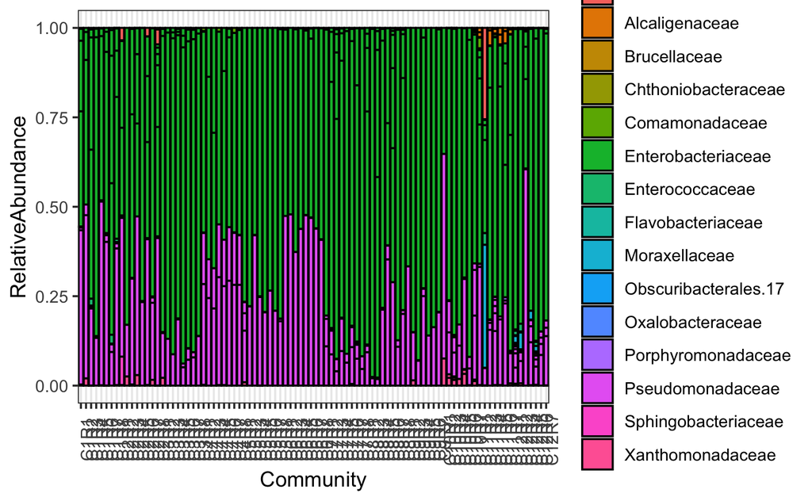

Abundances explained by ESVs in 13 communties

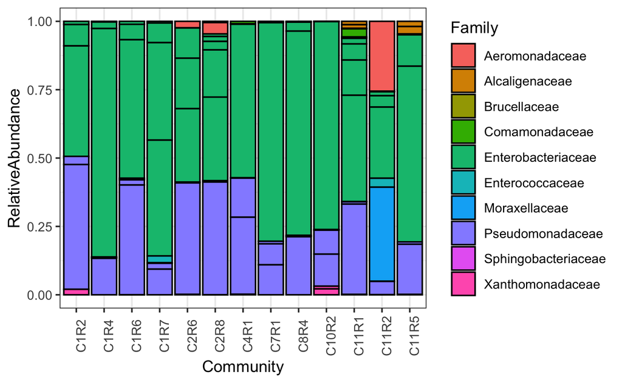

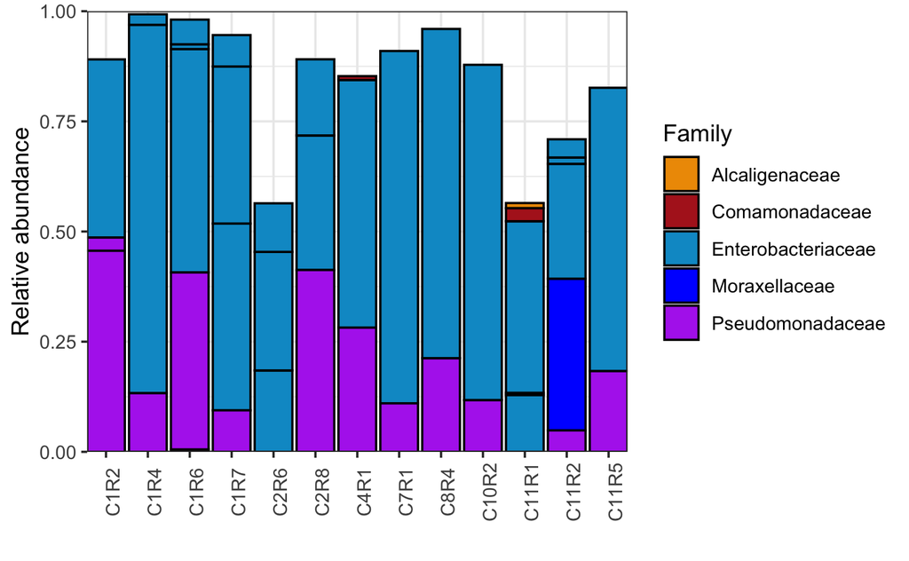

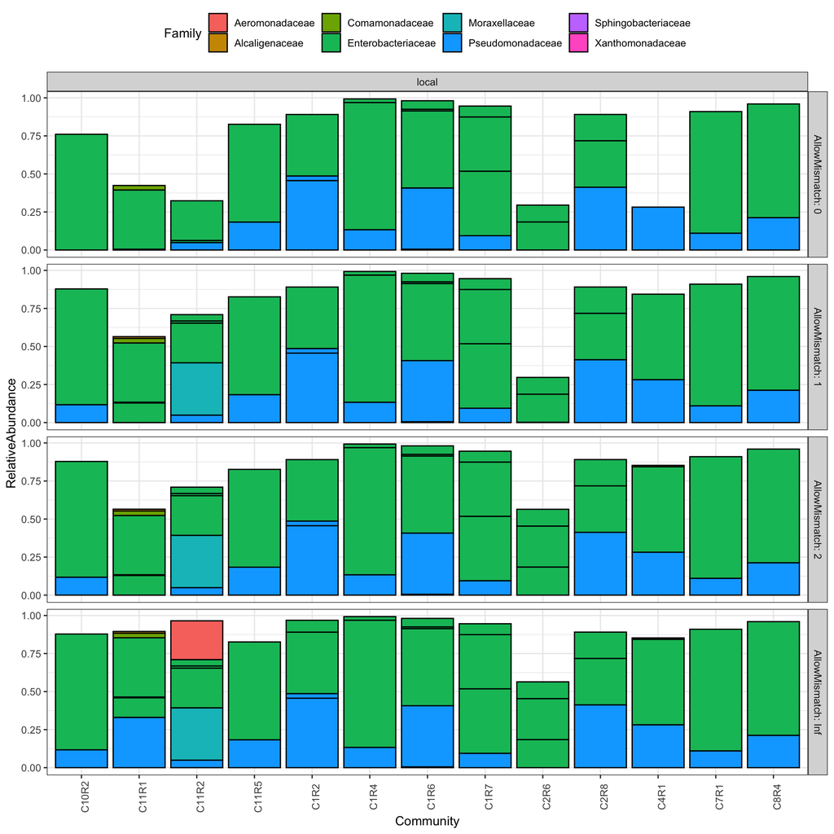